# Student Internship Selection Prediction using Logistic Regression

## Problem Statement

The internship selection process can involve multiple student-related factors that may influence the final selection outcome. Analyzing these factors manually can be time-consuming.

This project aims to use Machine Learning to predict internship selection outcomes and demonstrate how Logistic Regression can be applied to a binary classification problem.

### Import Libraries

```python
import pandas as pd
import numpy as np
import matplotlib.pyplot as plt
import seaborn as sns
```

```python
df = pd.read_csv("student_internship_selection (1).csv")
```

## Dataset Overview

```python
df.head()
```

|  | Record_ID | Age | CGPA | Attendance_Percent | Coding_Score | Communication_Score | Projects_Count | Certifications_Count | Technical_Skills | Aptitude_Score | Previous_Internship | Internship_Selected |
| --- | --- | --- | --- | --- | --- | --- | --- | --- | --- | --- | --- | --- |
| 0 | 1001 | 21 | 7.98 | 74.2 | 56.5 | 84.4 | 5.0 | 0.0 | Intermediate | 93.2 | No | 1 |
| 1 | 1002 | 18 | 8.73 | 71.1 | 57.2 | 76.5 | 4.0 | 1.0 | Intermediate | 57.7 | No | 1 |
| 2 | 1003 | 19 | 7.45 | 76.7 | 73.9 | 46.7 | 2.0 | 2.0 | NaN | 62.0 | No | 0 |
| 3 | 1004 | 19 | 8.10 | 80.6 | 89.2 | 85.2 | 1.0 | 4.0 | Intermediate | 73.7 | No | 1 |
| 4 | 1005 | 19 | 8.02 | 79.5 | 69.5 | 62.6 | 4.0 | 1.0 | Intermediate | 49.7 | No | 1 |

View First Few Rows

The df.head() output shows the first 5 rows of the student internship dataset and its main features such as Age, CGPA, Attendance, Coding Score, and Internship Selected.

```python
df.shape
```

```
(1500, 12)
```

Check Dataset Shape

The dataset contains 1500 rows and 12 columns.

```python
df.columns
```

```
Index(['Record_ID', 'Age', 'CGPA', 'Attendance_Percent', 'Coding_Score',
       'Communication_Score', 'Projects_Count', 'Certifications_Count',
       'Technical_Skills', 'Aptitude_Score', 'Previous_Internship',
       'Internship_Selected'],
      dtype='object')
```

Check Column Names

The dataset contains 12 columns representing student details, academic performance, skills, internship experience, and the internship selection outcome.

```python
df.dtypes
```

```
Record_ID                 int64
Age                       int64
CGPA                    float64
Attendance_Percent      float64
Coding_Score            float64
Communication_Score     float64
Projects_Count          float64
Certifications_Count    float64
Technical_Skills         object
Aptitude_Score          float64
Previous_Internship      object
Internship_Selected       int64
dtype: object
```

Check Data Types

The dataset contains numerical and categorical features. Numerical columns use integer or float data types, while Technical_Skills and Previous_Internship are categorical columns.

```python
df.info()
```

```
<class 'pandas.core.frame.DataFrame'>
RangeIndex: 1500 entries, 0 to 1499
Data columns (total 12 columns):
 #   Column                Non-Null Count  Dtype
---  ------                --------------  -----
 0   Record_ID             1500 non-null   int64
 1   Age                   1500 non-null   int64
 2   CGPA                  1480 non-null   float64
 3   Attendance_Percent    1480 non-null   float64
 4   Coding_Score          1480 non-null   float64
 5   Communication_Score   1480 non-null   float64
 6   Projects_Count        1480 non-null   float64
 7   Certifications_Count  1480 non-null   float64
 8   Technical_Skills      1480 non-null   object
 9   Aptitude_Score        1480 non-null   float64
 10  Previous_Internship   1480 non-null   object
 11  Internship_Selected   1500 non-null   int64
dtypes: float64(7), int64(3), object(2)
memory usage: 140.8+ KB
```

Dataset Information

The dataset contains 1500 entries and 12 columns. Some columns have 1480 non-null values, indicating the presence of missing values in the dataset.

Check dataset information

The dataset contains 1500 rows and 12 columns. The statistical summary provides information about the count, mean, standard deviation, minimum, maximum, and quartile values of the numerical features.

```python
df.describe()
```

|  | Record_ID | Age | CGPA | Attendance_Percent | Coding_Score | Communication_Score | Projects_Count | Certifications_Count | Aptitude_Score | Internship_Selected |
| --- | --- | --- | --- | --- | --- | --- | --- | --- | --- | --- |
| count | 1500.000000 | 1500.000000 | 1480.000000 | 1480.000000 | 1480.000000 | 1480.000000 | 1480.000000 | 1480.000000 | 1480.000000 | 1500.000000 |
| mean | 1733.443333 | 20.281333 | 7.169405 | 78.110338 | 68.271081 | 70.066284 | 2.189189 | 1.602703 | 66.114662 | 0.446667 |
| std | 425.250798 | 1.320864 | 1.047652 | 10.686675 | 15.342291 | 13.796465 | 1.478955 | 1.284534 | 15.063063 | 0.497313 |
| min | 1001.000000 | 18.000000 | 4.500000 | 45.000000 | 25.000000 | 30.000000 | 0.000000 | 0.000000 | 25.000000 | 0.000000 |
| 25% | 1364.750000 | 19.000000 | 6.470000 | 70.600000 | 57.600000 | 60.500000 | 1.000000 | 1.000000 | 56.275000 | 0.000000 |
| 50% | 1734.500000 | 20.000000 | 7.160000 | 78.300000 | 68.500000 | 70.300000 | 2.000000 | 1.000000 | 66.000000 | 0.000000 |
| 75% | 2100.250000 | 21.000000 | 7.862500 | 85.700000 | 79.400000 | 79.500000 | 3.000000 | 2.000000 | 75.925000 | 1.000000 |
| max | 2470.000000 | 24.000000 | 10.000000 | 100.000000 | 100.000000 | 100.000000 | 10.000000 | 9.000000 | 100.000000 | 1.000000 |

Statistical Summary

The df.describe() function provides statistical information such as count, mean, standard deviation, minimum, maximum, and quartile values for the numerical columns.

### Missing value

```python
df.isnull().sum()
```

```
Record_ID                0
Age                      0
CGPA                    20
Attendance_Percent      20
Coding_Score            20
Communication_Score     20
Projects_Count          20
Certifications_Count    20
Technical_Skills        20
Aptitude_Score          20
Previous_Internship     20
Internship_Selected      0
dtype: int64
```

### Check Missing Values

The dataset contains 20 missing values in several columns.

```python
df.duplicated().sum()
```

```
np.int64(25)
```

### Check Duplicate Values

The dataset contains 25 duplicate rows.

## Target Variable Analysis

The target variable is `Internship_Selected`, which represents the internship selection status of a student.

It is a binary variable with two possible outcomes:

- `0` → Student was not selected
- `1` → Student was selected

In this section, we examine the distribution of the two classes to understand whether the target variable is balanced or imbalanced.

```python
df["Internship_Selected"].value_counts()
```

```
Internship_Selected
0    830
1    670
Name: count, dtype: int64
```

```python
df["Internship_Selected"].value_counts(normalize=True) * 100
```

```
Internship_Selected
0    55.333333
1    44.666667
Name: proportion, dtype: float64
```

## Categorical Feature Analysis

```python
import pandas as pd

df = pd.read_csv("student_internship_selection (1).csv")
```

```python
df["Technical_Skills"].value_counts(dropna=False)
```

```
Technical_Skills
Intermediate    829
Advanced        384
Beginner        255
NaN              20
beginner          3
INTERMEDIATE      3
intermediate      2
BEGINNER          2
advanced          1
ADVANCED          1
Name: count, dtype: int64
```

### Check Technical Skills Distribution

The dataset contains different technical skill levels such as Beginner, Intermediate, and Advanced.

```python
df["Previous_Internship"].value_counts(dropna=False)
```

```
Previous_Internship
No     1114
Yes     354
NaN      20
no        6
NO        4
YES       2
Name: count, dtype: int64
```

### Check Previous Internship Distribution

The dataset contains Yes and No categories for previous internship experience.

## Numerical Feature Analysis

```python
df.select_dtypes(include=np.number).columns
```

```
Index(['Record_ID', 'Age', 'CGPA', 'Attendance_Percent', 'Coding_Score',
       'Communication_Score', 'Projects_Count', 'Certifications_Count',
       'Aptitude_Score', 'Internship_Selected'],
      dtype='object')
```

### Check Numerical Features

The dataset contains 10 numerical features.

```python
df.select_dtypes(include=np.number).describe()
```

|  | Record_ID | Age | CGPA | Attendance_Percent | Coding_Score | Communication_Score | Projects_Count | Certifications_Count | Aptitude_Score | Internship_Selected |
| --- | --- | --- | --- | --- | --- | --- | --- | --- | --- | --- |
| count | 1500.000000 | 1500.000000 | 1480.000000 | 1480.000000 | 1480.000000 | 1480.000000 | 1480.000000 | 1480.000000 | 1480.000000 | 1500.000000 |
| mean | 1733.443333 | 20.281333 | 7.169405 | 78.110338 | 68.271081 | 70.066284 | 2.189189 | 1.602703 | 66.114662 | 0.446667 |
| std | 425.250798 | 1.320864 | 1.047652 | 10.686675 | 15.342291 | 13.796465 | 1.478955 | 1.284534 | 15.063063 | 0.497313 |
| min | 1001.000000 | 18.000000 | 4.500000 | 45.000000 | 25.000000 | 30.000000 | 0.000000 | 0.000000 | 25.000000 | 0.000000 |
| 25% | 1364.750000 | 19.000000 | 6.470000 | 70.600000 | 57.600000 | 60.500000 | 1.000000 | 1.000000 | 56.275000 | 0.000000 |
| 50% | 1734.500000 | 20.000000 | 7.160000 | 78.300000 | 68.500000 | 70.300000 | 2.000000 | 1.000000 | 66.000000 | 0.000000 |
| 75% | 2100.250000 | 21.000000 | 7.862500 | 85.700000 | 79.400000 | 79.500000 | 3.000000 | 2.000000 | 75.925000 | 1.000000 |
| max | 2470.000000 | 24.000000 | 10.000000 | 100.000000 | 100.000000 | 100.000000 | 10.000000 | 9.000000 | 100.000000 | 1.000000 |

### Statistical Summary of Numerical Features

The statistical summary shows the count, mean, standard deviation, minimum, maximum, and quartile values of the numerical features.

## Outlier Analysis

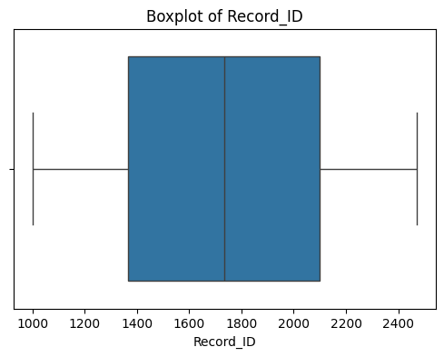

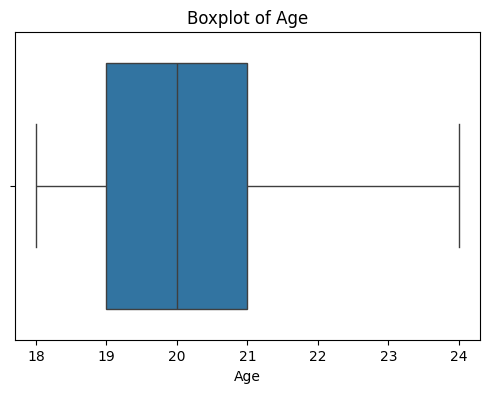

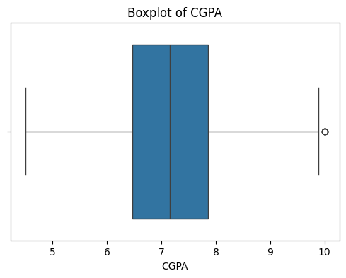

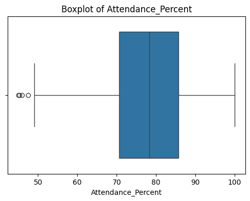

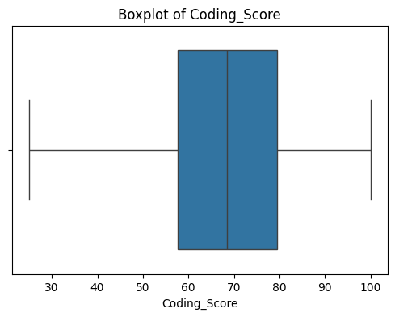

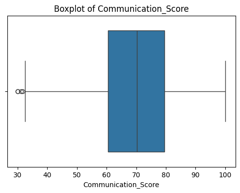

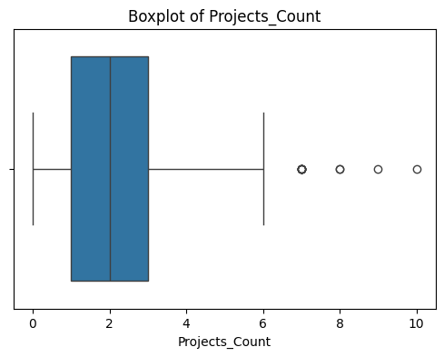

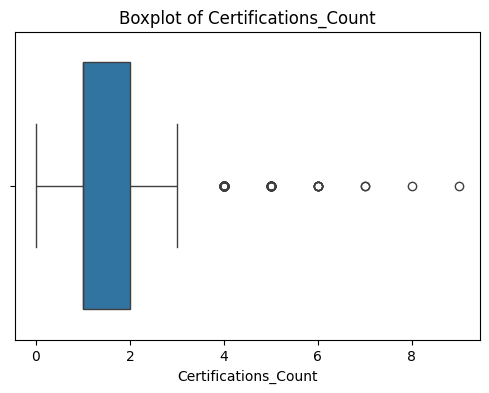

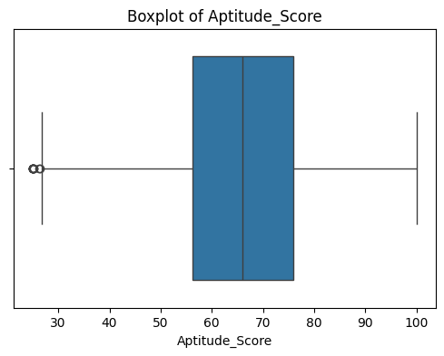

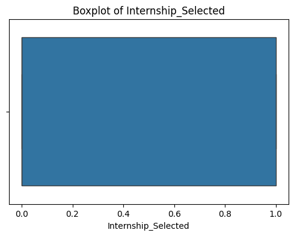

```python
numerical_columns = df.select_dtypes(include=np.number).columns

for column in numerical_columns:
    plt.figure(figsize=(6, 4))
    sns.boxplot(x=df[column])
    plt.title(f"Boxplot of {column}")
    plt.show()
```

### Check Numerical Feature Distribution

The distributions show the spread of numerical features such as Age, CGPA, Attendance, Coding Score, Communication Score, and Aptitude Score.

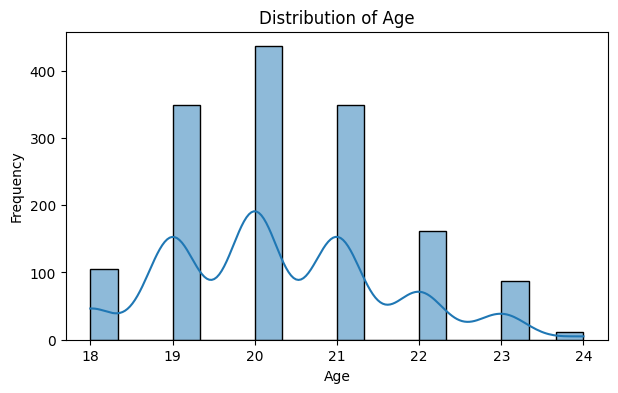

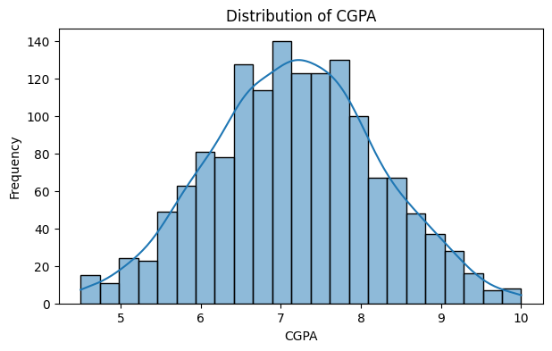

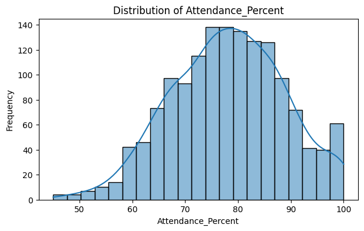

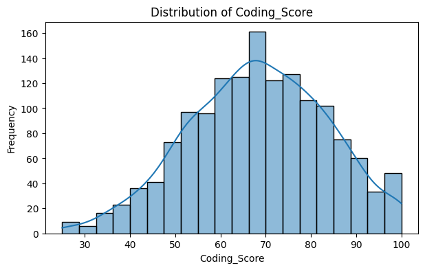

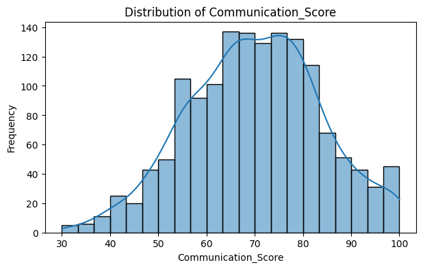

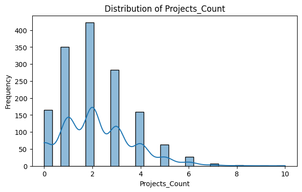

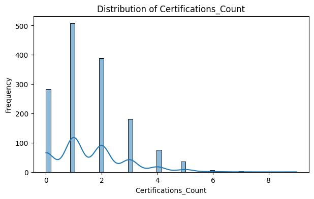

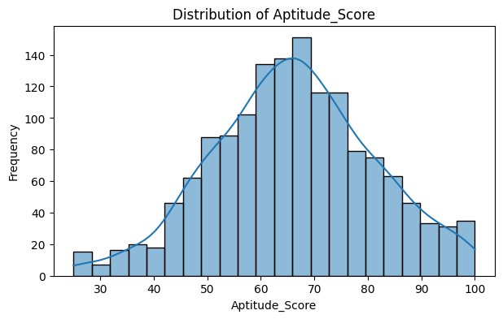

```python
numerical_features = [
    "Age",
    "CGPA",
    "Attendance_Percent",
    "Coding_Score",
    "Communication_Score",
    "Projects_Count",
    "Certifications_Count",
    "Aptitude_Score"
]

for column in numerical_features:
    plt.figure(figsize=(7, 4))
    sns.histplot(data=df, x=column, kde=True)
    plt.title(f"Distribution of {column}")
    plt.xlabel(column)
    plt.ylabel("Frequency")
    plt.show()
```

## Correlation Analysis

### Check Correlation Between Numerical Features

The correlation heatmap shows the relationships between numerical features such as Age, CGPA, Attendance, Coding Score, Communication Score, Projects Count, Certifications Count, and Aptitude Score.

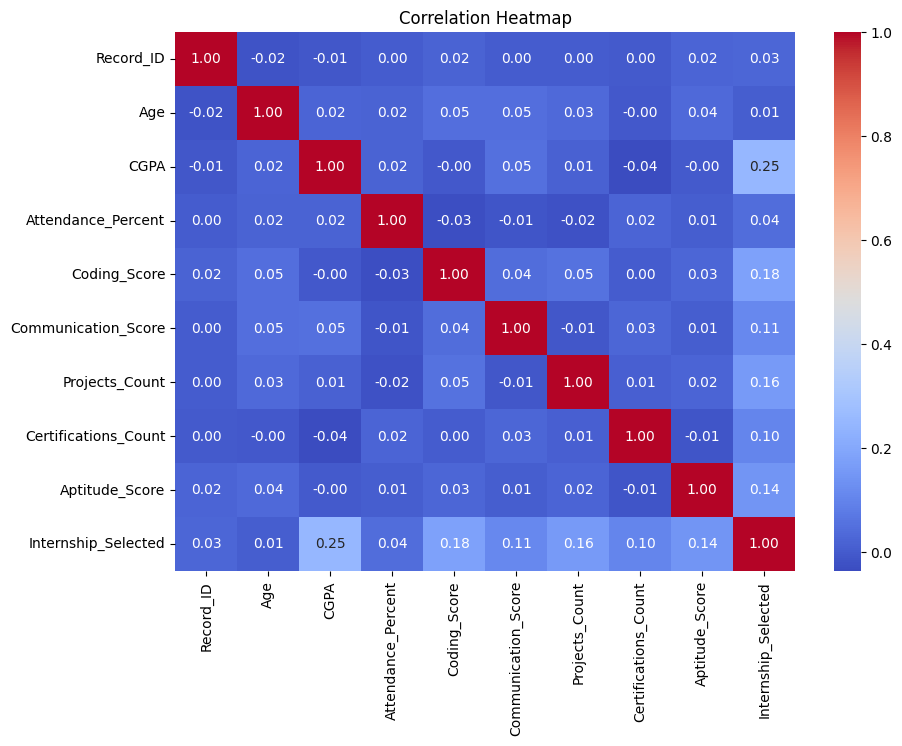

```python
correlation_matrix = df.select_dtypes(include=np.number).corr()

plt.figure(figsize=(10, 7))
sns.heatmap(correlation_matrix, annot=True, cmap="coolwarm", fmt=".2f")
plt.title("Correlation Heatmap")
plt.show()
```

## Categorical Feature Visualization

### Visualize Categorical Features

The plots show the distribution of Technical Skills and Previous Internship among the students.

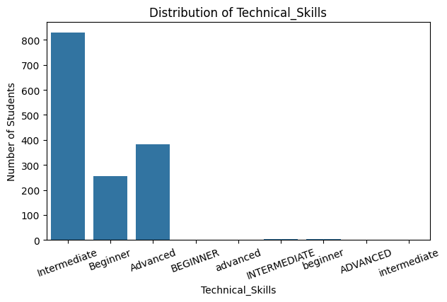

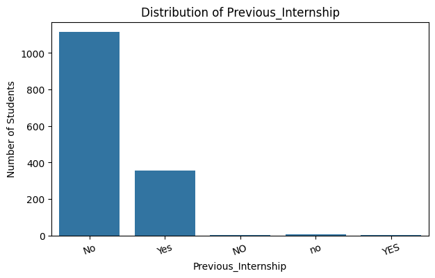

```python
categorical_features = ["Technical_Skills", "Previous_Internship"]

for column in categorical_features:
    plt.figure(figsize=(7, 4))
    sns.countplot(data=df, x=column)
    plt.title(f"Distribution of {column}")
    plt.xlabel(column)
    plt.ylabel("Number of Students")
    plt.xticks(rotation=20)
    plt.show()
```

## Data Cleaning

### Handling Missing Values

```python
# Separate numerical and categorical columns
numerical_cols = df.select_dtypes(include=np.number).columns
categorical_cols = df.select_dtypes(include="object").columns

# Fill numerical missing values with median
for column in numerical_cols:
    df[column] = df[column].fillna(df[column].median())

# Fill categorical missing values with mode
for column in categorical_cols:
    df[column] = df[column].fillna(df[column].mode()[0])

# Check missing values again
df.isnull().sum()
```

```
Record_ID               0
Age                     0
CGPA                    0
Attendance_Percent      0
Coding_Score            0
Communication_Score     0
Projects_Count          0
Certifications_Count    0
Technical_Skills        0
Aptitude_Score          0
Previous_Internship     0
Internship_Selected     0
dtype: int64
```

### Removing Duplicate Records

```python
# Check number of duplicate rows before removal
df.duplicated().sum()
```

```
np.int64(25)
```

```python
# Remove duplicate rows
df = df.drop_duplicates()

# Check the number of duplicate rows after removal
df.duplicated().sum()
```

```
np.int64(0)
```

```python
for col in df.select_dtypes(include="object").columns:
    print(f"\n{col}:")
    print(df[col].unique())
```

```
Technical_Skills:
['Intermediate' 'Beginner' 'Advanced' 'BEGINNER' 'advanced' 'INTERMEDIATE'
 'beginner' 'ADVANCED' 'intermediate']

Previous_Internship:
['No' 'Yes' 'NO' 'no' 'YES']
```

```python
# Check numerical columns
numerical_columns = df.select_dtypes(include='number').columns

numerical_columns
```

```
Index(['Record_ID', 'Age', 'CGPA', 'Attendance_Percent', 'Coding_Score',
       'Communication_Score', 'Projects_Count', 'Certifications_Count',
       'Aptitude_Score', 'Internship_Selected'],
      dtype='object')
```

```python
# Detect outliers using IQR method

Q1 = df[numerical_columns].quantile(0.25)
Q3 = df[numerical_columns].quantile(0.75)

IQR = Q3 - Q1

outliers = ((df[numerical_columns] < (Q1 - 1.5 * IQR)) |
            (df[numerical_columns] > (Q3 + 1.5 * IQR)))

outliers.sum()
```

```
Record_ID                 0
Age                       0
CGPA                      4
Attendance_Percent        4
Coding_Score              4
Communication_Score       5
Projects_Count           11
Certifications_Count    121
Aptitude_Score           12
Internship_Selected       0
dtype: int64
```

### Verify Clean Dataset

```python
print("Missing values:")
print(df.isnull().sum())

print("\nDuplicate rows:")
print(df.duplicated().sum())

print("\nDataset shape:")
print(df.shape)
```

```
Missing values:
Record_ID               0
Age                     0
CGPA                    0
Attendance_Percent      0
Coding_Score            0
Communication_Score     0
Projects_Count          0
Certifications_Count    0
Technical_Skills        0
Aptitude_Score          0
Previous_Internship     0
Internship_Selected     0
dtype: int64

Duplicate rows:
0

Dataset shape:
(1475, 12)
```

### Encode Categorical Variables

```python
# Encode categorical variables

X = pd.get_dummies(X, drop_first=True)

# Display the encoded features
X.head()
```

|  | Record_ID | Age | CGPA | Attendance_Percent | Coding_Score | Communication_Score | Projects_Count | Certifications_Count | Aptitude_Score | Technical_Skills_Advanced | ... | Technical_Skills_Beginner | Technical_Skills_INTERMEDIATE | Technical_Skills_Intermediate | Technical_Skills_advanced | Technical_Skills_beginner | Technical_Skills_intermediate | Previous_Internship_No | Previous_Internship_YES | Previous_Internship_Yes | Previous_Internship_no |
| --- | --- | --- | --- | --- | --- | --- | --- | --- | --- | --- | --- | --- | --- | --- | --- | --- | --- | --- | --- | --- | --- |
| 0 | 1001 | 21 | 7.98 | 74.2 | 56.5 | 84.4 | 5.0 | 0.0 | 93.2 | False | ... | False | False | True | False | False | False | True | False | False | False |
| 1 | 1002 | 18 | 8.73 | 71.1 | 57.2 | 76.5 | 4.0 | 1.0 | 57.7 | False | ... | False | False | True | False | False | False | True | False | False | False |
| 2 | 1003 | 19 | 7.45 | 76.7 | 73.9 | 46.7 | 2.0 | 2.0 | 62.0 | False | ... | False | False | True | False | False | False | True | False | False | False |
| 3 | 1004 | 19 | 8.10 | 80.6 | 89.2 | 85.2 | 1.0 | 4.0 | 73.7 | False | ... | False | False | True | False | False | False | True | False | False | False |
| 4 | 1005 | 19 | 8.02 | 79.5 | 69.5 | 62.6 | 4.0 | 1.0 | 49.7 | False | ... | False | False | True | False | False | False | True | False | False | False |

5 rows × 21 columns

### Train-Test Split

```python
from sklearn.model_selection import train_test_split

# Split the dataset into training and testing sets

X_train, X_test, y_train, y_test = train_test_split(
    X, y, test_size=0.2, random_state=42, stratify=y
)

print("Training features:", X_train.shape)
print("Testing features:", X_test.shape)
print("Training target:", y_train.shape)
print("Testing target:", y_test.shape)
```

```
Training features: (1180, 21)
Testing features: (295, 21)
Training target: (1180,)
Testing target: (295,)
```

### Feature Scaling

```python
from sklearn.preprocessing import StandardScaler

# Create StandardScaler object
scaler = StandardScaler()

# Fit and transform training data
X_train = scaler.fit_transform(X_train)

# Transform testing data
X_test = scaler.transform(X_test)
```

## Create Pipeline

A pipeline is created using StandardScaler for feature scaling and Logistic Regression for internship selection prediction.

### Logistic Regression Model.

```python
from sklearn.pipeline import Pipeline
from sklearn.preprocessing import StandardScaler
from sklearn.linear_model import LogisticRegression

pipeline = Pipeline([
    ('scaler', StandardScaler()),
    ('model', LogisticRegression(random_state=42))
])

pipeline
```

```
Pipeline(steps=[('scaler', StandardScaler()),
                ('model', LogisticRegression(random_state=42))])
```

### Import Logistic Regression

```python
model = LogisticRegression()

model
```

```
LogisticRegression()
```

### Create Logistic Regression Model

```python
# Create Logistic Regression model

model = LogisticRegression(random_state=42)

model
```

```
LogisticRegression(random_state=42)
```

### Train Logistic Regression Model

```python
model.fit(X_train, y_train)
```

```
LogisticRegression(random_state=42)
```

### Make Predictions

After training the Logistic Regression model, predictions are made using the testing dataset. The trained model predicts whether each student is selected or not selected for the internship.

```python
y_pred = model.predict(X_test)

y_pred[:10]
```

```
array([0, 0, 0, 1, 1, 0, 0, 0, 0, 1])
```

### Accuracy Score

```python
from sklearn.metrics import accuracy_score

# Calculate accuracy
accuracy = accuracy_score(y_test, y_pred)

print("Accuracy:", accuracy)
print("Accuracy (%):", accuracy * 100)
```

```
Accuracy: 0.711864406779661
Accuracy (%): 71.1864406779661
```

### Confusion Matrix

The model correctly predicted 119 Not Selected and 91 Selected cases. It incorrectly predicted 43 and 42 cases.

```python
from sklearn.metrics import confusion_matrix

# Calculate confusion matrix
cm = confusion_matrix(y_test, y_pred)

print("Confusion Matrix:")
print(cm)
```

```
Confusion Matrix:
[[119  43]
 [ 42  91]]
```

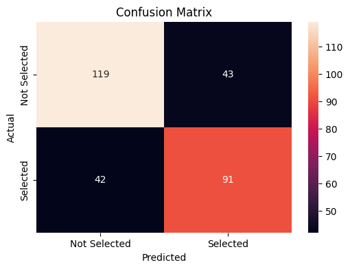

```python
# Visualize the confusion matrix

plt.figure(figsize=(6, 4))

sns.heatmap(
    cm,
    annot=True,
    fmt="d",
    xticklabels=["Not Selected", "Selected"],
    yticklabels=["Not Selected", "Selected"]
)

plt.xlabel("Predicted")
plt.ylabel("Actual")
plt.title("Confusion Matrix")
plt.show()
```

### Visualize Confusion Matrix

The heatmap shows the actual and predicted values for the Not Selected and Selected classes.

### Precision Score

The precision score shows how accurately the model identifies students who are actually selected among all students predicted as Selected.

```python
from sklearn.metrics import precision_score

# Calculate precision
precision = precision_score(y_test, y_pred)

print("Precision:", precision)
```

```
Precision: 0.6791044776119403
```

### Recall Score

```python
from sklearn.metrics import recall_score

# Calculate recall
recall = recall_score(y_test, y_pred)

print("Recall:", recall)
```

```
Recall: 0.6842105263157895
```

### F1 Score

```python
from sklearn.metrics import f1_score

# Calculate F1 Score
f1 = f1_score(y_test, y_pred)

print("F1 Score:", f1)
```

```
F1 Score: 0.6816479400749064
```

### Classification Report

The model achieved 71% accuracy. Not Selected has better performance (F1-score 0.74) than Selected (F1-score 0.68).

```python
from sklearn.metrics import classification_report

# Generate classification report
report = classification_report(
    y_test,
    y_pred,
    target_names=["Not Selected", "Selected"]
)

print(report)
```

```
              precision    recall  f1-score   support

Not Selected       0.74      0.73      0.74       162
    Selected       0.68      0.68      0.68       133

    accuracy                           0.71       295
   macro avg       0.71      0.71      0.71       295
weighted avg       0.71      0.71      0.71       295
```

### ROC-AUC / ROC Curve

```
ROC-AUC Score: 0.7535041306971131
```

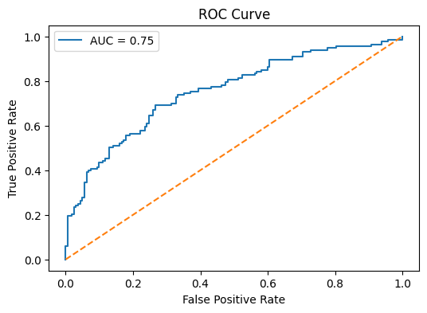

```python
from sklearn.metrics import roc_curve, roc_auc_score
import matplotlib.pyplot as plt

# Calculate prediction probabilities
y_prob = model.predict_proba(X_test)[:, 1]

# Calculate ROC curve
fpr, tpr, thresholds = roc_curve(y_test, y_prob)

# Calculate AUC
auc_score = roc_auc_score(y_test, y_prob)

print("ROC-AUC Score:", auc_score)

# Plot ROC Curve
plt.figure(figsize=(6, 4))
plt.plot(fpr, tpr, label=f"AUC = {auc_score:.2f}")
plt.plot([0, 1], [0, 1], linestyle="--")
plt.xlabel("False Positive Rate")
plt.ylabel("True Positive Rate")
plt.title("ROC Curve")
plt.legend()
plt.show()
```

### Model Performance Results

The model achieved 71.19% accuracy. The Precision, Recall, and F1 Score are approximately 67.91%, 68.42%, and 68.16%, respectively. The ROC-AUC score of 0.75 indicates a good ability to distinguish between Selected and Not Selected students.

```python
# Display model performance results

results = pd.DataFrame({
    "Metric": ["Accuracy", "Precision", "Recall", "F1 Score", "ROC-AUC"],
    "Score": [accuracy, precision, recall, f1, auc_score]
})

results
```

|  | Metric | Score |
| --- | --- | --- |
| 0 | Accuracy | 0.711864 |
| 1 | Precision | 0.679104 |
| 2 | Recall | 0.684211 |
| 3 | F1 Score | 0.681648 |
| 4 | ROC-AUC | 0.753504 |

### Conclusion

In this project, Exploratory Data Analysis, Data Cleaning, and Data Preprocessing were performed on the student internship dataset. The categorical features were encoded, the data was divided into training and testing sets, and feature scaling was applied.

A Logistic Regression model was trained to predict whether a student would be selected for an internship. The model was evaluated using Accuracy, Precision, Recall, F1 Score, and ROC-AUC Score.

The evaluation results provide an overall understanding of the model's classification performance and its ability to predict internship selection outcomes.

### Future Scope

The project can be further improved by using a larger and more diverse dataset containing additional student-related features. Other classification algorithms such as Decision Tree, Random Forest, and Support Vector Machine can also be tested and compared with Logistic Regression.

Hyperparameter tuning and cross-validation can be applied to improve model performance. The project can also be developed into a simple application that predicts internship selection based on student details.